# 計量経済学

課題2の解答例

矢内 勇生

2018-10-30

## パッケージの読み込み

解答に利用するパッケージを読み込む。

```r
library("tidyverse")
## Macユーザのみ次のコマンドも実行する
theme_set(theme_gray(base_size = 10,
                     base_family = "HiraginoSans-W3"))
```

## 1.5.2 （教科書 pp.40–43）

三つのデータセット (Kenya.csv; Sweden.csv; World.csv) をダウンロードし、dataディレクトリに保存する。

```r
download.file(url = "http://qss.princeton.press/student-files/INTRO/Kenya.csv",
              destfile = "data/Kenya.csv")
download.file(url = "http://qss.princeton.press/student-files/INTRO/Sweden.csv",
              destfile = "data/Sweden.csv")
download.file(url = "http://qss.princeton.press/student-files/INTRO/World.csv",
              destfile = "data/World.csv")
```

ダウンロードした三つのデータセットを読み込み、それぞれKenya、Sweden、World という名前のデータフレームを作る。

```r
Kenya <- read_csv("data/Kenya.csv")
Sweden <- read_csv("data/Sweden.csv")
World <- read_csv("data/World.csv")
```

データの中身を確認する。

```r
glimpse(Kenya)
```

```
## Observations: 30
## Variables: 8
## $ country  <chr> "KEN", "KEN", "KEN", "KEN", "KEN", "KEN", "KEN", "KEN...
## $ period   <chr> "1950-1955", "1950-1955", "1950-1955", "1950-1955", "...
## $ age      <chr> "0-4", "5-9", "10-14", "15-19", "20-24", "25-29", "30...
## $ births   <dbl> 0.000, 0.000, 0.000, 264.185, 485.564, 383.252, 268.6...
## $ deaths   <dbl> 398.314, 36.799, 19.520, 18.508, 21.361, 20.424, 18.9...
## $ py.men   <dbl> 2982.589, 1977.935, 1634.561, 1588.554, 1427.824, 120...
## $ py.women <dbl> 2977.828, 1969.698, 1633.975, 1564.652, 1364.061, 110...
## $ l_x      <dbl> 100000.000, 75157.419, 71364.502, 69469.475, 67421.14...
```

```r
glimpse(Sweden)
```

```
## Observations: 30
## Variables: 8
## $ country  <chr> "SWE", "SWE", "SWE", "SWE", "SWE", "SWE", "SWE", "SWE...
## $ period   <chr> "1950-1955", "1950-1955", "1950-1955", "1950-1955", "...
## $ age      <chr> "0-4", "5-9", "10-14", "15-19", "20-24", "25-29", "30...
## $ births   <dbl> 0.000, 0.000, 0.000, 40.823, 141.137, 160.882, 116.90...
## $ deaths   <dbl> 13.765, 1.302, 1.216, 1.581, 2.264, 2.885, 3.610, 4.7...
## $ py.men   <dbl> 1490.037, 1542.698, 1266.321, 1078.133, 1119.421, 130...
## $ py.women <dbl> 1410.502, 1470.816, 1217.133, 1049.193, 1105.129, 128...
## $ l_x      <dbl> 100000.00, 97575.29, 97308.11, 97093.74, 96733.76, 96...
```

```r
glimpse(World)
```

```
## Observations: 30
## Variables: 7
## $ country  <chr> "WORLD", "WORLD", "WORLD", "WORLD", "WORLD", "WORLD",...
## $ period   <chr> "1950-1955", "1950-1955", "1950-1955", "1950-1955", "...
## $ age      <chr> "0-4", "5-9", "10-14", "15-19", "20-24", "25-29", "30...
## $ births   <dbl> 0.000, 0.000, 0.000, 54238.336, 131939.226, 128063.23...
## $ deaths   <dbl> 101090.393, 7960.861, 5550.176, 5831.195, 6649.425, 6...
## $ py.men   <dbl> 946910.59, 726903.29, 666794.72, 626191.13, 573518.17...
## $ py.women <dbl> 904909.28, 694574.52, 635492.29, 600677.87, 555221.02...
```

### 1.

粗出生率（CBR）を計算する。 ケニア：

```r
periods <- unique(World$period)  # 期間を文字列のベクトルとして保存
Kenya_cbr <- Kenya %>%
  group_by(period) %>%
  summarize(py = sum(py.men) + sum(py.women),
            births = sum(births)) %>%
  mutate(cbr = births / py) %>%
  pull(cbr)
names(Kenya_cbr) <- periods
```

スウェーデン：

```r
Sweden_cbr <- Sweden %>%
  group_by(period) %>%
  summarize(py = sum(py.men) + sum(py.women),
            births = sum(births)) %>%
  mutate(cbr = births / py) %>%
  pull(cbr)
names(Sweden_cbr) <- periods
```

世界：

```r
World_cbr <- World %>%
  group_by(period) %>%
  summarize(py = sum(py.men) + sum(py.women),
            births = sum(births)) %>%
  mutate(cbr = births / py) %>%
  pull(cbr)
names(World_cbr) <- periods
```

結果を並べて表示する。

```r
rbind(Kenya_cbr, Sweden_cbr, World_cbr)
```

```
##             1950-1955  2005-2010
## Kenya_cbr  0.05209490 0.03851507
## Sweden_cbr 0.01539614 0.01192554
## World_cbr  0.03732863 0.02021593
```

1950年代に比べ、2000年代のCBRが低いことがわかる。また、いずれの期間においても、ケニアのCBRは世界全体より高く、スウェーデンのCBRは世界全体よりも低いことがわかる。

### 2.

まず、データセットで年齢がどのように記録されているか確認する。

```r
with(Kenya, table(age))
```

```
## age
##   0-4 10-14 15-19 20-24 25-29 30-34 35-39 40-44 45-49   5-9 50-54 55-59
##     2     2     2     2     2     2     2     2     2     2     2     2
## 60-69 70-79   80+
##     2     2     2
```

```r
with(Sweden, table(age))
```

```
## age
##   0-4 10-14 15-19 20-24 25-29 30-34 35-39 40-44 45-49   5-9 50-54 55-59
##     2     2     2     2     2     2     2     2     2     2     2     2
## 60-69 70-79   80+
##     2     2     2
```

```r
with(World, table(age))
```

```
## age
##   0-4 10-14 15-19 20-24 25-29 30-34 35-39 40-44 45-49   5-9 50-54 55-59
##     2     2     2     2     2     2     2     2     2     2     2     2
## 60-69 70-79   80+
##     2     2     2
```

5歳刻みの年齢グループに分けられていることがわかる。ただし、文字列として記録されているため、年齢順になっていない（5-9 より10-14が先に出てくる）。年齢順になるよう、age変数を因子 (factor) 型に変換しよう。

```r
Kenya <- Kenya %>%
  mutate(age = factor(age, levels = c("0-4", "5-9", "10-14", "15-19",
                                      "20-24", "25-29", "30-34", "35-39",
                                      "40-44", "45-49", "50-54", "55-59",
                                      "60-69", "70-79", "80+")))
with(Kenya, table(age))
```

```
## age
##   0-4   5-9 10-14 15-19 20-24 25-29 30-34 35-39 40-44 45-49 50-54 55-59
##     2     2     2     2     2     2     2     2     2     2     2     2
## 60-69 70-79   80+
##     2     2     2
```

```r
Sweden <- Sweden %>%
  mutate(age = factor(age, levels = c("0-4", "5-9", "10-14", "15-19",
                                      "20-24", "25-29", "30-34", "35-39",
                                      "40-44", "45-49", "50-54", "55-59",
                                      "60-69", "70-79", "80+")))
with(Sweden, table(age))
```

```
## age
##   0-4   5-9 10-14 15-19 20-24 25-29 30-34 35-39 40-44 45-49 50-54 55-59
##     2     2     2     2     2     2     2     2     2     2     2     2
## 60-69 70-79   80+
##     2     2     2
```

```r
World <- World %>%
  mutate(age = factor(age, levels = c("0-4", "5-9", "10-14", "15-19",
                                      "20-24", "25-29", "30-34", "35-39",
                                      "40-44", "45-49", "50-54", "55-59",
                                      "60-69", "70-79", "80+")))
with(World, table(age))
```

```
## age
##   0-4   5-9 10-14 15-19 20-24 25-29 30-34 35-39 40-44 45-49 50-54 55-59
##     2     2     2     2     2     2     2     2     2     2     2     2
## 60-69 70-79   80+
##     2     2     2
```

年齢別出生率 (ASFR) を、15以上50歳未満について求める。 ケニア：

```r
prod_age <- c( "15-19", "20-24", "25-29", "30-34",
               "35-39", "40-44", "45-49")
Kenya_asfr <- Kenya %>%
  filter(age %in% prod_age) %>%
  mutate(asfr = births / py.women)
```

スウェーデン：

```r
Sweden_asfr <- Sweden %>%
  filter(age %in% prod_age) %>%
  mutate(asfr = births / py.women)
```

世界：

```r
World_asfr <- World %>%
  filter(age %in% prod_age) %>%
  mutate(asfr = births / py.women)
```

スウェーデンとケニアの女性の出産パタンを確認する。

```r
bind_rows(Kenya_asfr, Sweden_asfr) %>%
  select(country, period, age, asfr) %>%
  spread(key = country, value = asfr)
```

```
## # A tibble: 14 x 4
##    period    age      KEN      SWE
##    <chr>     <fct>  <dbl>    <dbl>
##  1 1950-1955 15-19 0.169  0.0389
##  2 1950-1955 20-24 0.356  0.128
##  3 1950-1955 25-29 0.347  0.125
##  4 1950-1955 30-34 0.289  0.0874
##  5 1950-1955 35-39 0.206  0.0486
##  6 1950-1955 40-44 0.112  0.0162
##  7 1950-1955 45-49 0.0391 0.00134
##  8 2005-2010 15-19 0.101  0.00597
##  9 2005-2010 20-24 0.236  0.0507
## 10 2005-2010 25-29 0.233  0.116
## 11 2005-2010 30-34 0.181  0.132
## 12 2005-2010 35-39 0.131  0.0626
## 13 2005-2010 40-44 0.0563 0.0122
## 14 2005-2010 45-49 0.0382 0.000614
```

まず、いずれの期間でも、ケニアのASFRの方がスウェーデンのASFRよりどの年齢でも高い。また、スウェーデンでは20歳から34歳までの出産が比較的多いが、ケニアでは15歳から44歳までの範囲で多くの出産が見られる。ただし、10代と40代の出産は2000年代には減少している。

### 3.

各国の合計特殊出生率 (TFR) を求める。また、設問に答えるため、15歳以上50歳未満の女性数の合計も求める。 ケニア：

```r
Kenya_tfr_w <- Kenya_asfr %>%
  group_by(period) %>%
  summarize(women = sum(py.women),
            tfr = sum(asfr) * 5)
## TFRのベクトル
Kenya_tfr <- pull(Kenya_tfr_w, tfr)
names(Kenya_tfr) <- periods
## 女性数のベクトル
Kenya_women <- pull(Kenya_tfr_w, women)
names(Kenya_women) <- periods
```

スウェーデン：

```r
Sweden_tfr_w <- Sweden_asfr %>%
  group_by(period) %>%
  summarize(women = sum(py.women),
            tfr = sum(asfr) * 5)
## TFRのベクトル
Sweden_tfr <- pull(Sweden_tfr_w, tfr)
names(Sweden_tfr) <- periods
## 女性数のベクトル
Sweden_women <- pull(Sweden_tfr_w, women)
names(Sweden_women) <- periods
```

世界：

```r
World_tfr_w <- World_asfr %>%
  group_by(period) %>%
  summarize(women = sum(py.women),
            tfr = sum(asfr) * 5)
## TFRのベクトル
World_tfr <- pull(World_tfr_w, tfr)
names(World_tfr) <- periods
## 女性数のベクトル
World_women <- pull(World_tfr_w, women)
names(World_women) <- periods
```

女性数の変化を確認する。

```r
rbind(Kenya_women, Sweden_women, World_women)
```

```
##                1950-1955  2005-2010
## Kenya_women     7131.050   45946.28
## Sweden_women    8724.879   10308.44
## World_women  3222167.527 8680573.20
```

概して、世界の女性（15歳以上50歳未満）は増えている。二つの期間を比べると、ケニアでは女性数が6倍強になっている一方で、スウェーデンは20%ほどの増加である。世界では3倍弱の増加である。

出生数（TFR）を確認する。

```r
rbind(Kenya_tfr, Sweden_tfr, World_tfr)
```

```
##            1950-1955 2005-2010
## Kenya_tfr   7.591410  4.879568
## Sweden_tfr  2.226917  1.902764
## World_tfr   5.007248  2.543623
```

出生数は、全体的に減少していることが読み取れる。ケニアでは7.6から4.9へと大幅な減少が見られる。スウェーデンでの減少幅は役0.3と小さいが、これは1950年代の時点ですでに2.2という低水準であったためである。世界のTFRも5.0から2.5へと大きく減っている。

### 4.

粗死亡率（CDR）を計算する。 ケニア：

```r
Kenya_cdr <- Kenya %>%
  group_by(period) %>%
  summarize(py = sum(py.men) + sum(py.women),
            deaths = sum(deaths)) %>%
  mutate(cdr = deaths / py) %>%
  pull(cdr)
names(Kenya_cdr) <- periods
```

スウェーデン：

```r
Sweden_cdr <- Sweden %>%
  group_by(period) %>%
  summarize(py = sum(py.men) + sum(py.women),
            deaths = sum(deaths)) %>%
  mutate(cdr = deaths / py) %>%
  pull(cdr)
names(Sweden_cdr) <- periods
```

世界：

```r
World_cdr <- World %>%
  group_by(period) %>%
  summarize(py = sum(py.men) + sum(py.women),
            deaths = sum(deaths)) %>%
  mutate(cdr = deaths / py) %>%
  pull(cdr)
names(World_cdr) <- periods
```

結果を並べて表示する。

```r
rbind(Kenya_cdr, Sweden_cdr, World_cdr)
```

```
##              1950-1955   2005-2010
## Kenya_cdr  0.023962539 0.010389138
## Sweden_cdr 0.009844842 0.009968455
## World_cdr  0.019318929 0.008166083
```

CDRは世界全体で低下している。ケニアでは、粗死亡率約0.02から約0.01まで下がっており、世界全体と同様の傾向を示している。スウェーデンでは、二つの期間にほとんだ差はなく、少しだけ死亡率が上がっている。これは、1950年代時点でスウェーデンの死亡率が低かったためであると考えられる。スェーデンの死亡率は1950年代には世界全体と比べて低水準だったが、2000年代の死亡率は世界全体よりも高い。

### 5.

2005年から2010年までのケニアとスウェーデンの年齢別死亡率 (ASDR) を求める。 ケニア：

```r
Kenya_asdr <- Kenya %>%
  filter(period == "2005-2010") %>%
  mutate(asdr = deaths / (py.men + py.women))
```

スウェーデン：

```r
Sweden_asdr <- Sweden %>%
  filter(period == "2005-2010") %>%
  mutate(asdr = deaths / (py.women + py.men))
```

ASDRのパタンを確認する。

```r
Kenya_asdr %>%
  bind_rows(Sweden_asdr) %>%
  select(country, age, asdr) %>%
  spread(key = country, value = asdr)
```

```
## # A tibble: 15 x 3
##    age       KEN       SWE
##    <fct>   <dbl>     <dbl>
##  1 0-4   0.0209  0.000679
##  2 5-9   0.00291 0.0000814
##  3 10-14 0.00292 0.000114
##  4 15-19 0.00294 0.000269
##  5 20-24 0.00389 0.000470
##  6 25-29 0.00656 0.000494
##  7 30-34 0.0106  0.000506
##  8 35-39 0.0139  0.000669
##  9 40-44 0.0135  0.00104
## 10 45-49 0.0113  0.00177
## 11 50-54 0.0112  0.00299
## 12 55-59 0.0139  0.00471
## 13 60-69 0.0254  0.00983
## 14 70-79 0.0613  0.0280
## 15 80+   0.159   0.110
```

### 6.

スウェーデンの人口分布を用いて反事実的 (counterfactual) なケニアのCDRを算出する。 そのために、まず2005年から2010年の期間のスウェーデンの年齢別人口比率を計算する。

```r
Sweden_pop <- Sweden %>%
  filter(period == "2005-2010") %>%
  mutate(pop = py.men + py.women,
         ratio = pop / sum(pop)) %>%
  select(age, ratio)
```

求めた人口分布を使い、反事実的なケニアのCDR を計算する。

```r
Kenya_cdr_cf <- sum(Kenya_asdr$asdr * Sweden_pop$ratio)
```

実際のCDRと反事実的なCDRを比べる。

```r
c(Kenya = Kenya_cdr[2],
  Kenya_counterfactual = Kenya_cdr_cf,
  Sweden = Sweden_cdr[2])
```

```
##      Kenya.2005-2010 Kenya_counterfactual     Sweden.2005-2010
##          0.010389138          0.023216456          0.009968455
```

この分析から、ケニアがスウェーデンと同じような人口分布だったら、ケニアの粗死亡率の方がスウェーデンのそれよりもだいぶ高くなるだろうということが推測される。

## 2.8.2 （教科書 pp.99–101）

解答に必要なデータセットをダウンロードし、dataディレクトリに保存する。

```r
download.file(url = "http://qss.princeton.press/student-files/CAUSALITY/gay.csv",
              destfile = "data/gay.csv")
```

データを読み込み、Gayという名前のデータフレームを作る。

```r
Gay <- read_csv("data/gay.csv")
```

データの中身を確認する。

```r
glimpse(Gay)
```

```
## Observations: 69,592
## Variables: 4
## $ study     <int> 1, 1, 1, 1, 1, 1, 1, 1, 1, 1, 1, 1, 1, 1, 1, 1, 1, 1...
## $ treatment <chr> "No Contact", "No Contact", "No Contact", "No Contac...
## $ wave      <int> 3, 4, 1, 6, 2, 7, 7, 6, 1, 2, 5, 3, 4, 6, 2, 1, 4, 5...
## $ ssm       <int> 5, 5, 5, 5, 5, 5, 5, 4, 4, 4, 5, 3, 4, 5, 3, 5, 4, 5...
```

変数 treament がとる値を確認する。

```r
unique(Gay$treatment)
```

```
## [1] "No Contact"
## [2] "Recycling Script by Gay Canvasser"
## [3] "Same-Sex Marriage Script by Gay Canvasser"
## [4] "Recycling Script by Straight Canvasser"
## [5] "Same-Sex Marriage Script by Straight Canvasser"
```

値が文字列で与えらているが、それぞれの文字列が長い。 そこで、各値にcontrol, gay_recycle, gay_marriage, str_recycle, str_marriage ラベルを付け、因子型変数に変える。

```r
Gay <- Gay %>%
  mutate(treatment = factor(treatment,
                            levels = c("No Contact",
                                       "Recycling Script by Gay Canvasser",
                                       "Same-Sex Marriage Script by Gay Canvasser",
                                       "Recycling Script by Straight Canvasser",
                                       "Same-Sex Marriage Script by Straight Canvasser"),
                            labels = c("control", "gay_recycle", "gay_marriage",
                                       "str_recycle", "str_marriage")))
```

研究1と研究2をそれぞれStudy1とStudy2という名前のデータフレームにする。

```r
Study1 <- Gay %>%
  filter(study == 1) %>%
  select(-study)
Study2 <- Gay %>%
  filter(study == 2) %>%
  select(-study)
```

### 1.

研究1のデータを使い、処置 (treatment) の前（すなわち wave == 1）で、その後に受けた処置の違いによって、同性婚に対する意見 ssm が異なるかどうか調べる。

まず、基本的な統計量を比較してみる。

```r
Study1 %>%
  filter(treatment %in% c("control", "gay_marriage", "str_marriage"),
         wave == 1) %>%
  group_by(treatment) %>%
  summarize(mean = mean(ssm),
            sd = sd(ssm),
            min = min(ssm),
            median = median(ssm),
            max = max(ssm))
```

```
## # A tibble: 3 x 6
##   treatment     mean    sd   min median   max
##   <fct>        <dbl> <dbl> <dbl>  <dbl> <dbl>
## 1 control       3.04  1.68     1      3     5
## 2 gay_marriage  3.03  1.67     1      3     5
## 3 str_marriage  3.10  1.68     1      3     5
```

どのグループも、処置前のssmnの統計量は似通っているように見える。

分布も確認しよう（この部分は宿題ではできていなくてもよい）。

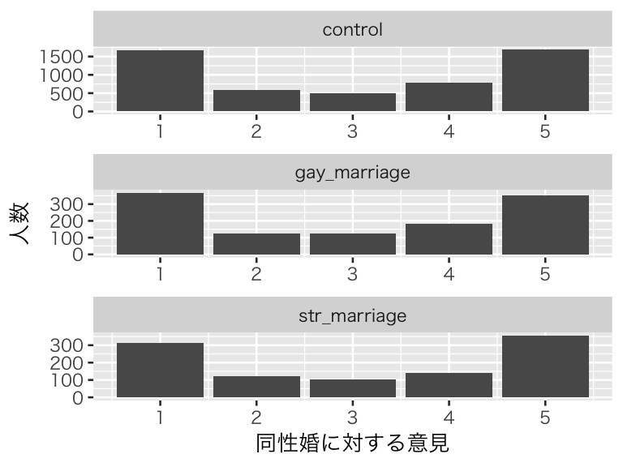

```r
balance_study1 <- Study1 %>%
  filter(treatment %in% c("control", "gay_marriage", "str_marriage"),
         wave == 1) %>%
  ggplot(aes(x = ssm)) +
    geom_bar() +
    facet_wrap(~ treatment, scales = "free", ncol = 1) +
    labs(x = "同性婚に対する意見", y = "人数")
print(balance_study1)
```

グループ別に見た回答の分布も似通っており、ランダム化がうまくいっているように見える。

### 2.

まず、統制群（比較群、コントロールグループ）である No Contact のssmの平均値を求める。

```r
s1w2_control <- Study1 %>%
  filter(wave == 2, treatment == "control") %>%
  with(mean(ssm))
```

次に、ゲイの訪問員が同性婚台本を読んだ場合のssmの平均値を求める。

```r
s1w2_gay_mar <- Study1 %>%
  filter(wave == 2,
         treatment == "gay_marriage") %>%
  with(mean(ssm))
```

同様に、ストレートの訪問員が同性婚台本を読んだ場合のssmの平均値と求める。

```r
s1w2_str_mar <- Study1 %>%
  filter(wave == 2,
         treatment == "str_marriage") %>%
  with(mean(ssm))
```

ゲイ訪問員の平均処置効果 (average treatment effet: ATE) を求める。

```r
s1w2_gay_mar - s1w2_control
```

```
## [1] 0.09987463
```

ゲイの訪問員が同性婚に関するメッセージを伝えることで、同性婚に対する支持の平均値が0.10ほど上昇した。

ストレート訪問員の平均処置効果を求める。

```r
s1w2_str_mar - s1w2_control
```

```
## [1] 0.122248
```

ストレートの訪問員が同性婚に関するメッセージを伝えることで、同性婚に対する支持の平均値が0.12ほど上昇した。

ゲイであるかストレートであるかに拘らず、同性婚に関するメッセージを受け取ることによって同性婚への支持が上昇することがわかる。また、ゲイとストレートの効果にあまり違いがない（ストレートの効果の方がやや大きい）ことから、訪問者の性的指向ではなく、台本を読むこと（あるいは単に人と会うこと）が意見の変化を促しているように読める。

### 3.

異なる種類の台本が用意されているのは、単に訪問員に会ったかどうかが重要なのか、台本の内容が重要なのかを区別できるようにするためである。

ゲイの訪問員がリサイクルを促す台本を読んだ場合のssmの平均値を求める。

```r
s1w2_gay_rec <- Study1 %>%
  filter(wave == 2,
         treatment == "gay_recycle") %>%
  with(mean(ssm))
```

同様に、ストレートの訪問員がリサイクルを促す台本を読んだ場合のssmの平均値と求める。

```r
s1w2_str_rec <- Study1 %>%
  filter(wave == 2,
         treatment == "str_recycle") %>%
  with(mean(ssm))
```

「ゲイの訪問員による同性婚台本」と「ゲイの訪問員によるリサイクル台本」の処置の結果を比較する。

```r
s1w2_gay_mar - s1w2_gay_rec
```

```
## [1] 0.03204239
```

ここから、単にゲイの訪問員に会ったという事実に加え、「同性婚に関する台本」という台本の内容が意見の変化を促したことが読み取れる。

同様に、「ストレートの訪問員による同性婚台本」と「ストレートの訪問員によるリサイクル台本」の処置を比較する。

```r
s1w2_str_mar - s1w2_str_rec
```

```
## [1] 0.1575845
```

この結果から、やはり単にストレートの訪問員に会ったという事実に加え、「同性婚に関する台本」という台本の内容が意見の変化を促したと考えられる。

### 4.

調査時点ごとに、ゲイとストレートの訪問員が同性婚台本を読んだときの平均処置効果 (ATE) を求める。

```r
ATE_waves <- Study1 %>%
  filter(treatment %in% c("control", "gay_marriage", "str_marriage")) %>%
  group_by(wave, treatment) %>%
  summarize(mean_ssm = mean(ssm)) %>%
  spread(key = treatment, value = mean_ssm) %>%
  mutate(ATE_gay = gay_marriage - control,
         ATE_str = str_marriage - control)
ATE_waves %>% select(wave, starts_with("ATE"))
```

```
## # A tibble: 7 x 3
## # Groups:   wave [7]
##    wave ATE_gay ATE_str
##   <int>   <dbl>   <dbl>
## 1     1 -0.0176  0.0569
## 2     2  0.0999  0.122
## 3     3  0.0814  0.0604
## 4     4  0.0926  0.0872
## 5     5  0.148   0.0986
## 6     6  0.0864  0.0635
## 7     7  0.0594 -0.0425
```

この結果を見ると、訪問員の効果はゲイとストレートで異なるようである。ストレートの訪問員の効果は、時間の経過ととともに少しずつ弱くなり、第7波の時点では消えてしまっている（マイナスになっている）。しかし、ゲイの訪問員の効果は、第6波までほとんど変わらずに持続し、第7波の時点でもまだ正の効果を示している。したがって、**この実験結果が正しければ**、訪問員がゲイの場合に接触効果が持続すると考えられる。

### 5.

1と同様のことをStudy2について行えばよい。 すなわち、処置 (treatment) の前（すなわち wave == 1）で、その後に受けた処置の違いによって、同性婚に対する意見 ssm が異なるかどうか調べる。

まず、基本的な統計量を比較してみる。

```r
Study2 %>%
  filter(wave == 1) %>%
  group_by(treatment) %>%
  summarize(mean = mean(ssm),
            sd = sd(ssm),
            min = min(ssm),
            median = median(ssm),
            max = max(ssm))
```

```
## # A tibble: 2 x 6
##   treatment     mean    sd   min median   max
##   <fct>        <dbl> <dbl> <dbl>  <dbl> <dbl>
## 1 control       2.97  1.68     1      3     5
## 2 gay_marriage  2.97  1.68     1      3     5
```

二つのグループ間で、処置前のssmnの統計量は似通っているように見える。

分布も確認しよう（この部分は宿題ではできていなくてもよい）。

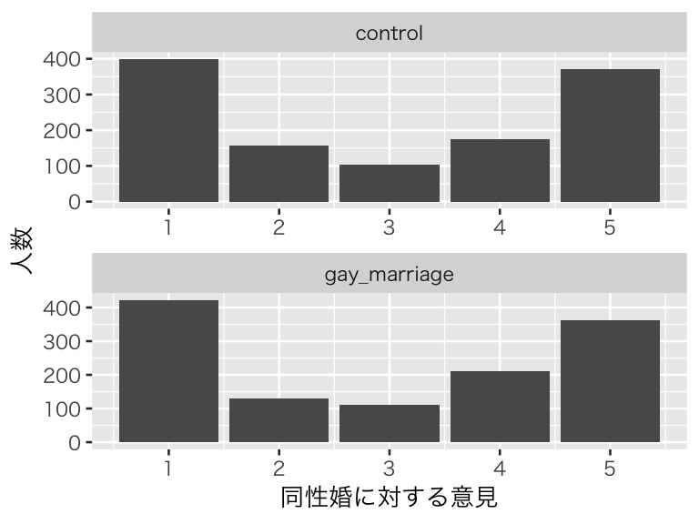

```r
balance_study2 <- Study2 %>%
  filter(wave == 1) %>%
  ggplot(aes(x = ssm)) +
    geom_bar() +
    facet_wrap(~ treatment, scales = "free", ncol = 1) +
    labs(x = "同性婚に対する意見", y = "人数")
print(balance_study2)
```

グループ別に見た回答の分布も似通っており、ランダム化がうまくいっているように見える。

### 6.

まず、統制群である No Contact のssmの平均値を求める。

```r
s2w2_control <- Study2 %>%
  filter(wave == 2, treatment == "control") %>%
  with(mean(ssm))
```

次に、ゲイの訪問員が同性婚台本を読んだ場合のssmの平均値を求める。

```r
s2w2_gay_mar <- Study2 %>%
  filter(wave == 2,
         treatment == "gay_marriage") %>%
  with(mean(ssm))
```

ゲイ訪問員の平均処置効果を求める。

```r
s2w2_gay_mar - s2w2_control
```

```
## [1] 0.1238937
```

ゲイの訪問員が同性婚に関するメッセージを伝えることで、同性婚に対する支持の平均値が0.12ほど上昇した。 Study1 では、第2波におけるゲイ訪問員の平均処置効果は 0.0998746だったので、実質的にほぼ同じ結果が得られたと考えられる。

### 7.

調査時点ごとに、ゲイの訪問員が同性婚台本を読んだときの平均処置効果 (ATE) を求める。

```r
ATE_waves_s2 <- Study2 %>%
  group_by(wave, treatment) %>%
  summarize(mean_ssm = mean(ssm)) %>%
  spread(key = treatment, value = mean_ssm) %>%
  mutate(ATE_gay2 = gay_marriage - control)
ATE_waves_s2 %>% select(wave, ATE_gay2)
```

```
## # A tibble: 5 x 2
## # Groups:   wave [5]
##    wave ATE_gay2
##   <int>    <dbl>
## 1     1  0.00165
## 2     2  0.124
## 3     3  0.150
## 4     4  0.125
## 5     7  0.307
```

同性婚台本を読むゲイの訪問員との接触効果が持続していることがわかる。

研究1と2から、同性婚台本を訪問員が読むことによって、同性婚への支持が増えることがわかる。しかし、その効果は、訪問員の性的指向によって異なる。訪問員がストレートのとき、接触効果は持続せず、1年経過すると効果は消えてしまう。他方、訪問員がゲイの場合には、接触効果が持続し、1年経っても一度上がった同性婚への支持は元の水準に下がることはない。

## 2.8.3 （教科書 pp.101–102）

解答に必要なデータセットをダウンロードし、dataディレクトリに保存する。

```r
download.file(url = "http://qss.princeton.press/student-files/CAUSALITY/leaders.csv",
              destfile = "data/leaders.csv")
```

```r
Leaders <- read_csv("data/leaders.csv")
```

データの中身を確認する。

```r
glimpse(Leaders)
```

```
## Observations: 250
## Variables: 11
## $ year           <int> 1929, 1933, 1934, 1924, 1931, 1968, 1992, 1908,...
## $ country        <chr> "Afghanistan", "Afghanistan", "Afghanistan", "A...
## $ leadername     <chr> "Habibullah Ghazi", "Nadir Shah", "Hashim Khan"...
## $ age            <int> 39, 53, 50, 29, 36, 41, 73, 48, 76, 77, 51, 52,...
## $ politybefore   <dbl> -6.000000, -6.000000, -6.000000, 0.000000, -9.0...
## $ polityafter    <dbl> -6.000000, -7.333333, -8.000000, -9.000000, -9....
## $ interwarbefore <int> 0, 0, 0, 0, 0, 0, 0, 0, 0, 0, 0, 0, 1, 1, 1, 0,...
## $ interwarafter  <int> 0, 0, 0, 0, 0, 0, 0, 0, 0, 0, 0, 0, 1, 0, 0, 0,...
## $ civilwarbefore <int> 1, 0, 0, 0, 0, 0, 0, 0, 0, 0, 0, 0, 0, 0, 0, 0,...
## $ civilwarafter  <int> 0, 0, 0, 0, 0, 0, 1, 0, 0, 0, 0, 0, 0, 0, 0, 0,...
## $ result         <chr> "not wounded", "dies within a day after the att...
```

### 1.

このデータの観測単位が暗殺計画なので、暗殺計画の数はこのデータの観測の数 (the number of observations; obs.) である。RStudio ではこの値はEnvironmentタブのデータフレーム名の右側に表示されているが、念のためデータフレームの行数を確認する。

```r
nrow(Leaders)
```

```
## [1] 250
```

次に、少なくとも一度はリーダーの暗殺計画があった国の数を数える。country の値のうちユニークなものを取り出し、その数を数えればよい。

```r
unique(Leaders$country) %>% length()
```

```
## [1] 88
```

88か国で少なくとも1回はリーダーの暗殺計画があったことが把握されている。

続いて、年平均何件の暗殺計画があったかを調べる。そのためにまず、国ごとの年平均暗殺計画数を数える。

ここで、年平均の数え方は複数あり得る。まず、すべての国が同じ期間観察されたと仮定しよう。 データフレームでyearの最大値と最小値を確認する。

```r
summary(Leaders$year)
```

```
##    Min. 1st Qu.  Median    Mean 3rd Qu.    Max.
##    1878    1920    1949    1945    1972    2001
```

ここから、1878年から2001年までの観察があることがわかる。すなわち、観察された期間は、124年である。 平均値を計算する際の分母にはこの値を使う。

```r
Assassin_1 <- Leaders %>%
  group_by(country) %>%
  summarize(avg_assassin = n() / (2001 - 1878 + 1))
mean(Assassin_1$avg_assassin)
```

```
## [1] 0.02291056
```

年平均で0.023件の暗殺計画があったことがわかる。

次に、国によってデータセットに含まれる期間が異なると仮定して分析しよう。 国ごとに、データセットに初めて登場した年から最後に登場した年までの期間のみ観察されていたと仮定する。

```r
Assassin_2 <- Leaders %>%
  group_by(country) %>%
  summarize(total = n(),  # n() で行数が数えられる
            rec_years = max(year) - min(year) + 1) %>%
  mutate(avg_assassin = total / rec_years)
mean(Assassin_2$avg_assassin)
```

```
## [1] 0.5307185
```

年平均0.53回の暗殺計画があったことがわかる。

最後に、国ごとに観察期間が異なるという仮定を維持し、最後に平均値を計算するときに観察期間に応じた重みをつけて平均値を計算し直そう。

```r
Assassin_3 <- Leaders %>%
  group_by(country) %>%
  summarize(total = n(),  # n() で行数が数えられる
            rec_years = max(year) - min(year) + 1)
with(Assassin_3, sum(total) / sum(rec_years))
```

```
## [1] 0.1212415
```

年平均0.12回程度の暗殺計画があったことがわかる。

このように、データセットがどのように集められたか（に関する仮定）によって、計算する値が大きく異なり得ることに注意が必要である。

### 2.

暗殺計画の結果resultの中身を確認する。

```r
with(Leaders, table(result))
```

```
## result
##               dies between a day and a week
##                                           2
##             dies between a week and a month
##                                           2
##          dies within a day after the attack
##                                          46
##                        dies, timing unknown
##                                           4
## hospitalization but no permanent disability
##                                          20
##                                 not wounded
##                                          96
##                                plot stopped
##                                          40
##               survives but wounded severely
##                                           1
##           survives, whether wounded unknown
##                                          14
##                             wounded lightly
##                                          25
```

指導者が死亡したかどうかは、resultの値が “dies” から始まっているかどうかで判定できることがわかる。 文字列に特定の表現が含まれるかどうかは、`stringr::str_detect()`で判定できる。stringrもtidyverseに含まれている。 `str_detect(判定の対象, 含まれるかどうか確認したい文字列)` という使い方をする。結果は、文字列が含まれていればTRUE、含まれなければFALSEである。

```r
Leaders <- Leaders %>%
  mutate(success = ifelse(str_detect(result, "dies"), 1, 0))
```

できた変数を確認しよう。

```r
Leaders %>%
  with(table(result, success)) %>%
  addmargins()
```

```
##                                              success
## result                                          0   1 Sum
##   dies between a day and a week                 0   2   2
##   dies between a week and a month               0   2   2
##   dies within a day after the attack            0  46  46
##   dies, timing unknown                          0   4   4
##   hospitalization but no permanent disability  20   0  20
##   not wounded                                  96   0  96
##   plot stopped                                 40   0  40
##   survives but wounded severely                 1   0   1
##   survives, whether wounded unknown            14   0  14
##   wounded lightly                              25   0  25
##   Sum                                         196  54 250
```

250の暗殺計画のうち、成功（指導者が死亡）したのは約20パーセントの54回である。 暗殺を計画すれば必ず指導者が死ぬわけではないという意味で、暗殺の成功はランダムに決まると言える。しかし、成功と失敗の確率に大きな差があり、結果が失敗に偏っていることから、「確率が半々」という意味でのランダムではないと考えることも可能である。

### 3.

暗殺計画までの3年間のポリティ指標の平均値と狙われた指導者の平均年齢を、暗殺成功と失敗の計画に分けて求める。

```r
Leaders %>%
  group_by(success) %>%
  summarize(mean_politybefore = mean(politybefore),
            mean_age = mean(age))
```

```
## # A tibble: 2 x 3
##   success mean_politybefore mean_age
##     <dbl>             <dbl>    <dbl>
## 1       0            -1.74      52.7
## 2       1            -0.704     56.5
```

暗殺が成功した場合と失敗した場合で、ポリティ指標におおよそ1程度の差がある。 年齢には、4歳程度のさがある。 これらの結果は、暗殺が成功する場合と失敗する場合とでは、政治体制や指導者の年齢がそもそも異なることを示唆している。つまり、暗殺の成否はランダムに決まっていないかもしれないことが窺える。

### 4.

まず、暗殺計画前の3年間に内戦または国家間戦争があった場合は1、そうでない場合は0をとるwarbeforeという変数を作り、この変数の平均値が成功した暗殺計画と失敗した計画の間で異なるかどうか確認する。

```r
Leaders %>%
  mutate(warbefore = ifelse(civilwarbefore + interwarbefore == 0, 0, 1)) %>%
  group_by(success) %>%
  summarize(mean_warbefore = mean(warbefore))
```

```
## # A tibble: 2 x 2
##   success mean_warbefore
##     <dbl>          <dbl>
## 1       0          0.372
## 2       1          0.352
```

暗殺計画前の3年間に戦争状態があったかどうかについては、二つのグループ間に大きな違いは見られない。この点に関しては、あたかもランダムのように見える。

### 5.

#### **民主化**

暗殺が成功した計画について、暗殺前後の各3年間のポリティ指標の平均値の差を計算する。

```r
dif_killed <- Leaders %>%
  filter(success == 1) %>%
  with(mean(polityafter) - mean(politybefore))
dif_killed
```

```
## [1] -0.05864198
```

暗殺が成功した場合、ポリティ指標の変化は-0.0586である。

同様に、暗殺が失敗した計画について、暗殺前後の各3年間のポリティ指標の平均値の差を計算する。

```r
dif_survived <- Leaders %>%
  filter(success == 0) %>%
  with(mean(polityafter) - mean(politybefore))
dif_survived
```

```
## [1] -0.1513605
```

暗殺が失敗した場合、ポリティ指標の変化は-0.1514である。

ここで、暗殺が成功した国で、もし暗殺がなかったら暗殺が失敗した国と同じようにポリティ指標が推移すると仮定する。 すると、ここで計算した二つの平均値の差の差 (difference in differences) が暗殺の平均処置効果（平均因果効果）を表すと考えられる。 計算すると、

```r
(dif_in_difs <- dif_killed - dif_survived)
```

```
## [1] 0.09271857
```

となる（式全体をカッコで囲むと代入と表示を同時に実行する）。ポリティ指標にほとんど変化が見られないことから、指導者の暗殺成功が民主化の原因になるとは言えない。

#### **戦争**

暗殺が成功した計画について、暗殺前後の各3年間の戦争発生の平均値の差を計算する。

```r
dif_killed_war <- Leaders %>%
  filter(success == 1) %>%
  mutate(warbefore = ifelse(civilwarbefore + interwarbefore == 0, 0, 1),
         warafter = ifelse(civilwarafter + interwarafter == 0, 0, 1)) %>%
  with(mean(warafter) - mean(warbefore))
dif_killed_war
```

```
## [1] -0.1481481
```

暗殺が成功した場合、戦争の割合の変化は-0.1481である。

同様に、暗殺が失敗した計画について、暗殺前後の各3年間の戦争発生の平均値の差を計算する。

```r
dif_survived_war <- Leaders %>%
  filter(success == 0) %>%
  mutate(warbefore = ifelse(civilwarbefore + interwarbefore == 0, 0, 1),
         warafter = ifelse(civilwarafter + interwarafter == 0, 0, 1)) %>%
  with(mean(warafter) - mean(warbefore))
dif_survived_war
```

```
## [1] -0.07653061
```

暗殺が失敗した場合、戦争発生割合の変化は-0.0765である。

ここで、暗殺が成功した国で、もし暗殺がなかったら暗殺が失敗した国と同じように戦争発生割合が推移すると仮定する。 すると、ここで計算した二つの平均値の差の差が戦争発生に関する暗殺の平均処置効果（平均因果効果）を表すと考えられる。 計算すると、

```r
(dif_in_difs_war <- dif_killed_war - dif_survived_war)
```

```
## [1] -0.07161754
```

となる。戦争発生確率が上昇していないので、指導者の暗殺が戦争を引き起こすとは言えない。むしろ、戦争の確率を下げているようである。

授業の内容に戻る